# Insécurité alimentaire au Niger

# 1 Cartes thématiques

## 1.1 Proportion de la population en situation d’insécurité sévère par département

Le graphique suivant illustre la distribution spatiale de la population victime d’insécurité alimentaire sévère au Niger en 2018. Les départements les plus touchés sont ceux de N’Guigmi (16.7%), de Bilma (16.0%), de Tillia (12.6%) et de Ouallam (12.5%). Ceux les moins concernés par une insécurité alimemtaire sévère sont Aderbissinat (0%), Bermo (0%), Damagaram Takaya (0%), Dosso (0%) et dans une moindre mesure Dioundiou (0.3%) et Aguié(0.4%).

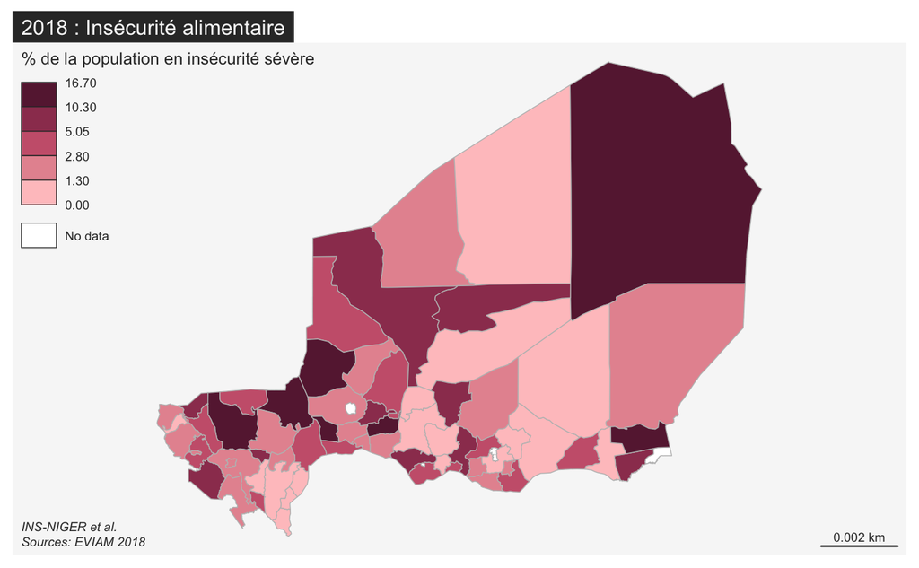

## 1.2 Différentes cartes thématiques par région

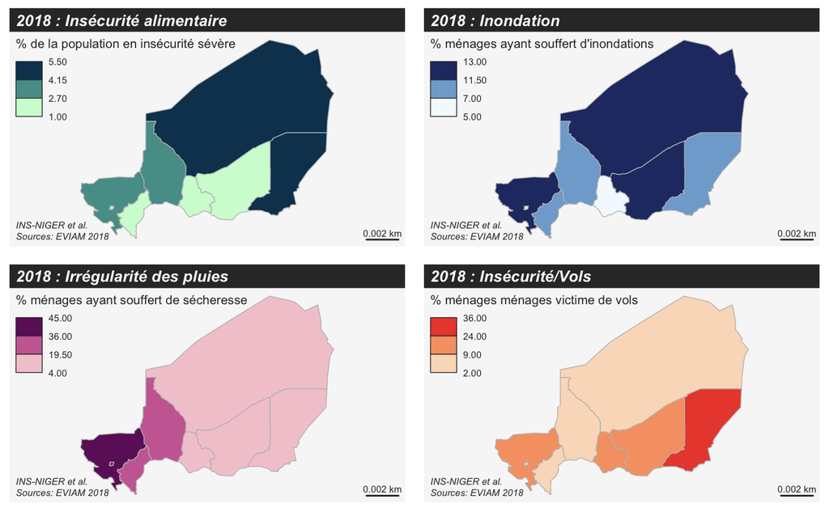

# 2 Modéles de régression logistique

Le tableau ci-dessous met en exergue les liens existants entre les chocs et la malnutrition au Niger dans les années 2019 et 2020.

En 2019, les ménages ayant remboursés leurs dettes (OR=3.44,p<0.001), étant victimes de de chômage de longue durée(OR=3.20,p<0.001), de perte d’emplois (OR=2.50,p<0.001) ou dans une moindre mesure d’augmentation des prix des denrées alimentaires (OR=1.96,p<0.001) étaient plus à risque d’insuffisance alimentaire. En 2020, ce sont prioritairement les ménages victimes de perte d’emplois (OR=5.86,p<0.001), d’augmentation du prix du loyer (OR=3.79,p<0.001) ayant remboursés leurs dettes (OR=3.72,p<0.001), victimes de chômage de longue durée (OR=3.61,p<0.001), d’inondations (OR=2.30,p<0.001) ou dans une moindre mesure d’irrégularité des pluies (OR=1.98,p<0.001) qui étaient plus sujettes à une malnutrition.

Nonobstant ces faits, l’association entre la malnutrition et, d’une part, la baisse de revenu et d’autre part, les dépenses de santé exceptionnelles peut s’expliquer par le coût relativement élevé des denrées alimentaires et le pouvoir d’achat des ménages. Lequel pouvoir diminuerait sous l’effet d’une baisse de revenu ou d’une dépense de santé exceptionnelle. Par ailleurs, les inondations et l’irrégularité des pluies favoriseraient la rareté des denrées alimentaires sur les marchés locaux et de facto l’augmentation de leur prix de vente. En effet, le risque pour les ménages ayant des faibles revenus et victimes de dépenses de santé (OR<sub>2019</sub>=1.70; OR<sub>2020</sub>=2.88,p<0.001 pour les deux années); ceux victimes de conditions climatiques désastreuses et ayant un accès difficile aux denrées alimentaires (OR<sub>2019</sub>=1.63; OR<sub>2020</sub>=2.17,p<0.001 pour les deux années) ainsi que ceux victimes de la cherté de la vie (OR<sub>2019</sub>=1.91; OR<sub>2020</sub>=1.55,p<0.001 pour les deux années) ont un risque relativement important de malnutrition.

Tableau 1. Liens associatifs entre chocs et malnutrition au Niger

| **Choc** | 2019 **OR**<sup>1,2</sup> | 2019 **95% CI**<sup>2</sup> | 2019 **p-valeur** | 2020 **OR**<sup>3,2</sup> | 2020 **95% CI**<sup>2</sup> | 2020 **p-valeur** |
| --- | --- | --- | --- | --- | --- | --- |
| Inondations | 1,23 | 1,03 – 1,46 | 0,024 | 2,30 | 1,99 – 2,66 | <0,001 |
| Sécheresse | 1,24 | 1,13 – 1,37 | <0,001 | 1,98 | 1,67 – 2,34 | <0,001 |
| Baisse des récoltes | 1,64 | 1,49 – 1,80 | <0,001 | 1,42 | 1,26 – 1,61 | <0,001 |
| Météo désastreuse & accés difficiles aux denrées alimentaires | 1,63 | 1,45 – 1,84 | <0,001 | 2,17 | 1,82 – 2,59 | <0,001 |
| Augmentation des prix des denrées alimentaires | 1,96 | 1,79 – 2,14 | <0,001 | 1,64 | 1,44 – 1,86 | <0,001 |
| Augmentation des prix du transport | 1,04 | 0,84 – 1,28 | 0,7 | 1,64 | 1,36 – 1,97 | <0,001 |
| Augmentation des prix du loyer | 1,44 | 0,93 – 2,17 | 0,10 | 3,79 | 2,70 – 5,31 | <0,001 |
| Augmentation des prix des intrants agricoles | 1,40 | 1,22 – 1,60 | <0,001 | 1,74 | 1,49 – 2,02 | <0,001 |
| Augmentation du coût de la vie | 1,91 | 1,75 – 2,09 | <0,001 | 1,55 | 1,37 – 1,76 | <0,001 |
| Perte d'emploi | 2,50 | 2,15 – 2,90 | <0,001 | 5,86 | 4,88 – 7,04 | <0,001 |
| Chômage de longue durée | 3,20 | 2,78 – 3,67 | <0,001 | 3,61 | 2,97 – 4,37 | <0,001 |
| Sans emploi | 2,50 | 2,15 – 2,90 | <0,001 | 5,86 | 4,88 – 7,04 | <0,001 |
| Baisse de revenu | 1,39 | 1,27 – 1,51 | <0,001 | 1,78 | 1,57 – 2,02 | <0,001 |
| Dépenses de santé exceptionnelles | 1,55 | 1,42 – 1,70 | <0,001 | 1,70 | 1,50 – 1,93 | <0,001 |
| Remboursement de dettes | 3,44 | 3,07 – 3,85 | <0,001 | 3,72 | 3,09 – 4,47 | <0,001 |
| Faible revenu & dépenses de santé exceptionnelles | 1,70 | 1,53 – 1,88 | <0,001 | 2,88 | 2,50 – 3,32 | <0,001 |
| Insécurité /vols | 1,16 | 1,03 – 1,31 | 0,016 | 1,51 | 1,29 – 1,76 | <0,001 |

<sup>*1*</sup> Odds ratio issus d'un modèle de régression logistique multivarié prenant en compte,comme variables indépendantes, en plus du choc, le statut du ménage (autochtone ou non), le sexe du chef du ménage (CM), le niveau d'instruction du CM, le niveau de vie du ménage, la taille du ménage et la région de résidence. <sup>*2*</sup> OR = rapport de cotes, CI = intervalle de confiance <sup>*3*</sup> Le modèle de régression logistique multivarié de 2020 est ajusté sur les mêmes variables que celui de 2019 à l'exception du sexe et du niveau d'instruction du chef de ménage.

> `Attention:` Les résultats de 2020 ne concerne que 5 régions sur 7 régions.

# 3 Pyramides des âges du Niger

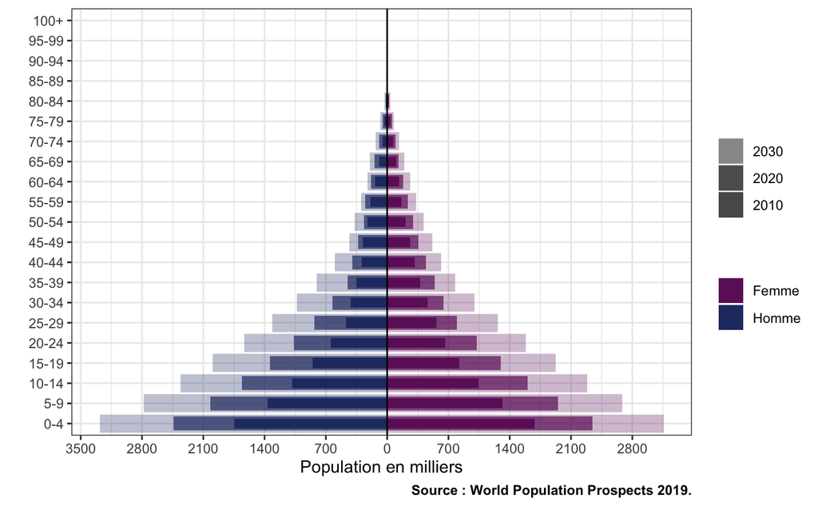